### Part II

#### OPEN BOOK

Tuesday, May 21, 2013

**4.** Suppose $Y_1, Y_2, \dots, Y_n$ are i.i.d. $Weibull(\gamma, \alpha, \beta)$ random variables, where $- \infty < \gamma < \infty, \ \alpha > 0$, and $\beta > 0$, with density $f(y \ \big| \ \gamma, \alpha, \beta) = \frac{\alpha}{\beta^{\alpha}}(y - \gamma)^{\alpha - 1} \exp \bigg[ - \bigg( \frac{y - \gamma}{\beta}\bigg)^{\alpha} \bigg]$ for $y > 0$ and $0$ otherwise. Note that $\begin{aligned} E[Y] &= \gamma + \beta \ \Gamma \bigg(\frac{1}{\alpha} + 1 \bigg) \\ \text{Var}(Y) &= \beta^2 \bigg[ \Gamma \bigg(\frac{2}{\alpha} + 1 \bigg) - \Gamma \bigg(\frac{1}{\alpha} + 1 \bigg)^2 \bigg] \end{aligned}$ Assume the location parameter $\gamma = 0$. The shape parameter is $\alpha$ and the parameter $\beta$ is the scale parameter.

1. Determine the likelihood function of $\alpha$ and $\beta$, $L(\alpha, \beta)$.  
   **Solution**  
   $\begin{align*} L(\alpha, \beta) &= f(y_1, \dots, y_n \ | \ \alpha, \beta) \\ &= \prod_{i=1}^n f(y_i | \alpha, \beta) \\ &= \prod_{i=1}^n \frac{\alpha}{\beta^{\alpha}}y_i^{\alpha - 1} \exp \left\{- \left( \frac{y_i}{\beta}\right)^{\alpha} \right\} \\ &= \frac{\alpha^n}{\beta^{n \alpha}} \left( \prod_{i=1}^n y_i^{\alpha -1} \right) \exp \left\{ - \sum_{i=1}^n \frac{y_i^{\alpha}}{\beta^{\alpha}} \right\} \end{align*}$
2. Determine the log-likelihood function of $\alpha$ and $\beta$, $\ell(\alpha, \beta)$.  
   **Solution**  
   $\begin{align*} \ell (\alpha, \beta) &= \log L(\alpha, \beta) \\ &= n \log \alpha - n \alpha \log \beta + (\alpha - 1) \sum_{i=1}^n \log y_i - \frac{1}{\beta^{\alpha}} \sum_{i=1}^n y_i^{\alpha} \end{align*}$
3. Show the two equations that need to be satisfied to compute the maximum likelihood estimators (MLEs), $\hat{\alpha}$ and $\hat{\beta}$, of $\alpha$ and $\beta$, respectively.  
   **Solution**  
   $\frac{\partial}{\partial \alpha} \ell (\alpha, \beta) = 0$  
   $\frac{\partial}{\partial \beta} \ell (\alpha, \beta) = 0$  
   $\begin{align*} \frac{\partial}{\partial \beta} \ell (\alpha, \beta) &= - \frac{n \alpha}{\beta} + \alpha \beta^{- \alpha -1} \sum_{i=1}^n y_i^{\alpha} \\ 0 &= - \frac{n \alpha}{\beta} + \alpha \beta^{- \alpha -1} \sum_{i=1}^n y_i^{\alpha} \\ \frac{n \alpha}{\beta} &= \alpha \beta^{- \alpha -1} \sum_{i=1}^n y_i^{\alpha} \\ n \alpha &= \beta \cdot \alpha \beta^{- \alpha -1} \sum_{i=1}^n y_i^{\alpha} \\ n \alpha &= \alpha \frac{1}{\beta^{\alpha}} \sum_{i=1}^n y_i^{\alpha} \\ n \alpha \cdot \beta^{\alpha} &= \alpha \sum_{i=1}^n y_i^{\alpha} \\ \beta^{\alpha} &= \frac{1}{n}\sum_{i=1}^n y_i^{\alpha} \\ \hat{\beta} &= \left( \frac{1}{n}\sum_{i=1}^n y_i^{\alpha} \right)^{1/\alpha} \end{align*}$ Before determining the MLE of $\alpha$, note: $\begin{align*} \frac{\partial}{\partial \alpha} y^{\alpha} &= \frac{\partial}{\partial \alpha} \exp \{ \log y^{\alpha} \} \\ &= \frac{\partial}{\partial \alpha} \exp \{ \alpha \log y \} \\ &= \exp \{ \alpha \log y \} \cdot \log y \\ &= \exp \{ \log y^{\alpha} \} \cdot \log y \\ &= y^{\alpha} \log y \end{align*}$ (Unclear why that was necessary). $\begin{align*} \frac{\partial}{\partial \alpha} \ell (\alpha, \beta) &= \frac{\partial}{\partial \alpha} \Bigg[ n \log \alpha - n \alpha \log \beta + (\alpha - 1) \sum_{i=1}^n \log y_i - \frac{1}{\beta^{\alpha}} \sum_{i=1}^n y_i^{\alpha} \Bigg] \\ &= \frac{n}{\alpha} - n \log \beta + \sum_{i=1}^n \log y_i - \frac{1}{\beta^{\alpha}} \sum_{i=1}^n y_i^{\alpha} \log y_i \tag*{(Need to apply chain rule to last term)} \\ \end{align*}$ Then plug in $\hat{\beta}$ and solve for $\alpha$ . . .
4. Name a function in the software package `R` that can be used to compute the MLEs.  
   **Solution**  
   `nlm()` or `uniroot()` or `mle()` or `optimize()`.
5. Run the beginning parts of the `R` program `Weibull.R` to simulate the data set to be used and to plot the density estimator. Does the distribution of the data look skewed? Is the Weibull model an appropriate model to consider for modeling these data (assuming you did not know how the data was simulated)? What is the first data value in the data set $y$?  
   **Solution**  
   “Skewed to the right.”  
   “Yes, the Weibull model is for positive variables.”  
   $y_1=10.87$

```r
### Maximum Likelihood Estimates for the Weibull Distribution

set.seed(1234)

# simulate the data  RUN THIS PART OF THE CODE ONLY ONCE

alpha = 1   # shape
beta = 5    # scale

n = 100

y = rweibull(n, alpha, beta)

mean(y);var(y); sd(y)
```

```
## [1] 5.788966
```

```
## [1] 24.81692
```

```
## [1] 4.981658
```

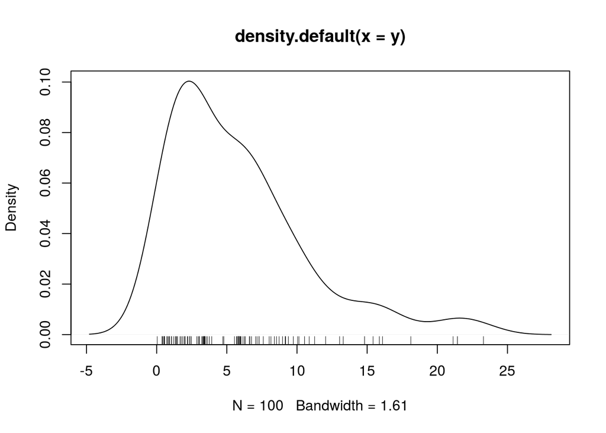

```r
# plot the simulated data

plot(density(y))
rug(y)
```

```r
#########################################################################

# evaluate the log Likelihood at two different values of beta

logL.5 = sum(dweibull(y, shape = 1, scale = 5, log = TRUE))
logL.5
```

```
## [1] -276.7231
```

```r
logL.7 = sum(dweibull(y, shape = 1, scale = 7, log = TRUE))
logL.7
```

```
## [1] -277.2905
```

```r
# minimize -logL

logL = function(x){
      -sum(dweibull(y, shape = x[1], scale = x[2], log = TRUE))
}

y.mle = nlm(logL, c(shape = 1, scale = 5), hessian = TRUE)
y.mle
```

```
## $minimum
## [1] 273.8512
##
## $estimate
## [1] 1.163893 6.104529
##
## $gradient
## [1]  3.418732e-06 -8.566745e-07
##
## $hessian
##            [,1]      [,2]
## [1,] 133.675825 -6.927845
## [2,]  -6.927845  3.633637
##
## $code
## [1] 1
##
## $iterations
## [1] 11
```

```r
# Asymptotic variance

AV = solve(y.mle$hessian); AV
```

```
##             [,1]      [,2]
## [1,] 0.008301009 0.0158266
## [2,] 0.015826595 0.3053811
```

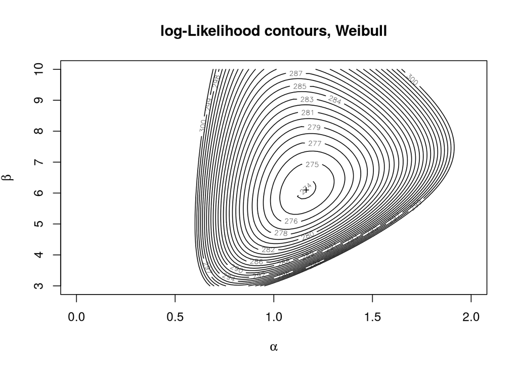

```r
# contour plot

len = 101

grid = matrix(0.0, nrow = len, ncol = len)
shape.vals = seq(0, 2, len = len)
scale.vals = seq(3, 10, len = len)

for(i in seq(along = shape.vals)){
      for(j in seq(along = scale.vals)){
            grid[i,j] = logL(c(shape.vals[i],scale.vals[j]))
      }
}
contour(shape.vals, scale.vals, grid, levels = 200:300)
points(y.mle$estimate[1],y.mle$estimate[2], pch = "+")
title(main = "log-Likelihood contours, Weibull", xlab = expression(alpha),
      ylab = expression(beta))
```

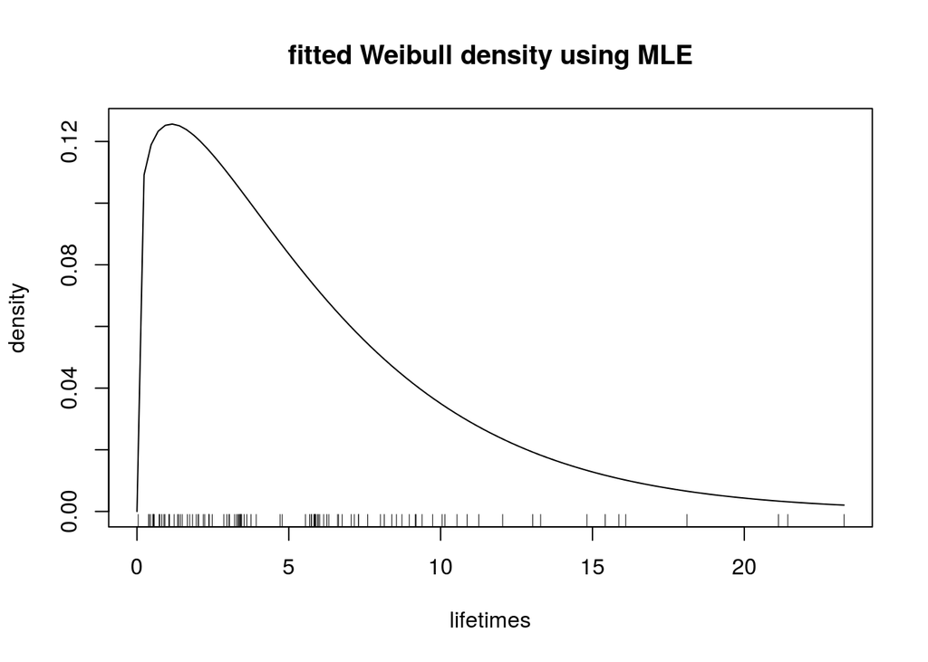

```r
# plot fitted weibull model

plot(function(y) dweibull(y, shape = y.mle$estimate[1],
      scale = y.mle$estimate[2]), 0, max(y), xlab = "lifetimes",
      ylab = "density", main = "fitted Weibull density using MLE")
rug(y)
```

```r
# CI alpha

y.mle$estimate[1]
```

```
## [1] 1.163893
```

```r
y.mle$estimate[1] - 1.96*sqrt(AV[1,1]); y.mle$estimate[1] + 1.96*sqrt(AV[1,1])
```

```
## [1] 0.9853178
```

```
## [1] 1.342469
```

```r
# CI beta

y.mle$estimate[2]
```

```
## [1] 6.104529
```

```r
y.mle$estimate[2] - 1.96*sqrt(AV[2,2]); y.mle$estimate[2] + 1.96*sqrt(AV[2,2])
```

```
## [1] 5.021408
```

```
## [1] 7.187651
```

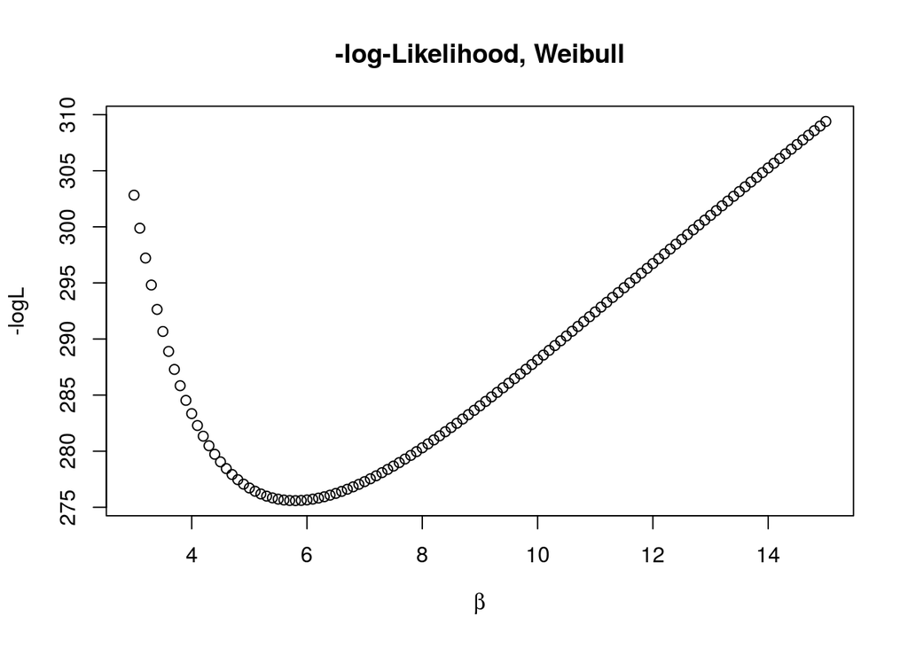

```r
#########################################################################

# Test H_0: alpha = 1 versus H_1: alpha != 1

# Fix alpha = 1, examine the profile likelihood of beta

# examine the profile log-Likelihood of beta for fixed alpha = 1

profile.logL = function(beta){
      -sum(dweibull(y, shape = 1, scale = beta, log = TRUE))
}

# plot the profile likelihood for beta

scale.index = seq(3,15,0.1)

yy = numeric()

for(i in 1: length(scale.index)) {
      yy[i] = profile.logL(scale.index[i])
}

plot(scale.index, yy, xlab = expression(beta), ylab = "-logL",
      main = "-log-Likelihood, Weibull")
```

```r
# minimize -logL

y.mle2 = nlm(profile.logL, c(beta = 4.0), hessian = TRUE)

y.mle2
```

```
## $minimum
## [1] 275.5954
##
## $estimate
## [1] 5.788963
##
## $gradient
## [1] 1.963855e-08
##
## $hessian
##          [,1]
## [1,] 2.982807
##
## $code
## [1] 1
##
## $iterations
## [1] 9
```

```r
# CI beta

y.mle2$estimate
```

```
## [1] 5.788963
```

```r
y.mle2$estimate - 1.96*sqrt(y.mle2$hessian^-1)
```

```
##        [,1]
## [1,] 4.6541
```

```r
y.mle2$estimate + 1.96*sqrt(y.mle2$hessian^-1)
```

```
##          [,1]
## [1,] 6.923826
```

```r
# Test H_0: beta = 5 versus H_1: beta != 5
```

6. Consider two Weibull distributions to compare, $Weibull (\alpha = 1, \beta = 5)$ and $Weibull (\alpha = 1, \beta = 7)$, which model is more likely?  
   **Solution**  
   $Weibull (\alpha = 1, \beta = 5)$  
   $\begin{align*} \log L(\beta = 5) &> \log L(\beta=7) \\ -276 &> -277 \end{align*}$
7. Compute the MLEs of $\alpha$ and $\beta$. Give the computed values of $\hat{\alpha}$ and $\hat{\beta}$ from `R`.  
   **Solution**  
   $\begin{align*} \hat{\alpha} &= 1.16 \\ \hat{\beta} &= 6.10 \end{align*}$
8. [1 point] What does the `log = TRUE` option in the `dweibull` function do?  
   **Solution**  
   “The `log = TRUE` option takes the log of the density value. It makes computing the log-likelihood easy.”
9. Examine the contour plot of the log-likelihood function. What is in the middle of the contour plot?  
   **Solution**  
   $(\hat{\alpha}, \hat{\beta})$
10. Test $H_0: \alpha = 1$ versus $H_1: \alpha \neq 1$ using the 95% Confidence Interval for $\alpha$.  
    **Solution**  
    Fail to reject $H_0$.  
    $(0.985, 1.342)$
11. Now assuming $\alpha =1$, examine the profile log-likelihood of $\beta$. What is the newly computed value of MLE of $\beta$? What is the name of the distribution being fit to these data?  
    **Solution**  
    $\hat{\beta}= 5.79$  
    The distribution is $Exp(\beta)$.
12. Test $H_0: \beta = 5$ versus $H_1: \beta \neq 5$ using the 95% Confidence Interval for $\beta$.  
    **Solution**  
    Fail to reject $H_0$.  
    $(4.65, 6.92)$
13. If $Y_1, Y_2, \dots, Y_n$ are i.i.d. $Exp(\beta)$, where $\beta > 0$, with density $f(y \ | \ \beta) = \frac{1}{\beta} \exp \bigg[ - \bigg(\frac{y}{\beta} \bigg) \bigg]$ for $y > 0$ and $0$ otherwise.  
    Determine the MLE of $\beta$, the asymptotic variance (AV), and give a large sample 95% Confidence Interval for $\beta$. Compute the interval, for the simuated data $y$. Compare your answer with the interval used in part (l).  
    **Solution**  
    $Y_1, \dots, Y_n \stackrel{iid}{\sim} Exp(\beta)$  
    $f(y_i | \beta) = \frac{1}{\beta} \exp \{ -\frac{y}{\beta}\}$  
    $\begin{align*} L(\beta) &= f(y_1, \dots, y_n | \beta) \\ &= \prod_{i=1}^n f(y_i | \beta) \\ &= \prod_{i=1}^n \frac{1}{\beta} \exp \left\{ - \frac{y_i}{\beta} \right\} \\ &= \frac{1}{\beta^n} \exp \left\{ - \sum_{i=1}^n \frac{y_i}{\beta} \right\} \\ \ell(\beta) &= \log \left( \frac{1}{\beta^n} \exp \left\{ - \sum_{i=1}^n \frac{y_i}{\beta} \right\} \right) \\ &= -n \log \beta - \frac{1}{\beta} \sum_{i=1}^n y_i \\ \frac{\partial}{\partial \beta}\ell(\beta) &= -\frac{n}{\beta} + \frac{1}{\beta^2} \sum_{i=1}^n y_i \\ 0 &= -\frac{n}{\beta} + \frac{1}{\beta^2} \sum_{i=1}^n y_i \\ \frac{n}{\beta} &= \frac{1}{\beta^2} \sum_{i=1}^n y_i \\ \hat{\beta} &= \frac{1}{n}\sum_{i=1}^n y_i \\ &= \overline{y} \\ &= 5.79 \end{align*}$ Compute AV $\begin{align*} \log f(y | \beta) &= - \log \beta - \frac{y}{\beta} \\ \frac{\partial}{\partial \beta} \log f(y | \beta) &= - \frac{1}{\beta} + \frac{y}{\beta^2} \\ \frac{\partial^2}{\partial \beta^2} \log f(y | \beta) &= \frac{1}{\beta^2} - 2 \frac{y}{\beta^3} \end{align*}$ $\begin{align*} I(\beta) &= - E \left[ \frac{\partial^2}{\partial \beta^2} \log f(y | \beta) \right] \\ &= - E \left[ \frac{1}{\beta^2} - 2 \frac{Y}{\beta^3} \right] \\ &= - \frac{1}{\beta^2} + \frac{2}{\beta^3}E[Y] \\ &= - \frac{1}{\beta^2} + \frac{2}{\beta^3} \beta \\ &= \frac{1}{\beta^2} \end{align*}$ So $A.V. = \frac{1}{n I(\beta)} = \frac{\beta^2}{n}$ 95% confidence interval for $\beta$: $\begin{align*} \hat{\beta} &\pm 1.96 \sqrt{\frac{\hat{\beta}^2}{n}} \\ \overline{y} &\pm 1.96 \frac{\overline{y}}{\sqrt{n}} = (4.65, 6.92) \end{align*}$